# Week 7 - Multiple Regression 2

Flora Le (flora.le@monash.edu)

2023-08-20

# 1 Intro

This week we continue our lessons on multiple regression, including checking assumptions and running regression models with both continuous and categorical variables.

# 2 Packages

First thing first. Open your R project and load the packages.

```r
library(data.table)
library(psych)
library(car)
library(ggplot2)
library(JWileymisc)
library(extraoperators)
library(lm.beta)
library(visreg)
library(olsrr)
```

A new package to help test multicollinearity.

```r
#install.packages("corrplot)
library(corrplot)
```

# 3 Data

Let’s start by loading a dataset for this week called “week7_dataset.csv”.

```r
d <- fread("week7_dataset.csv")
```

# 4 Assumptions for Multiple Regression Models

**Exercise**

Run a regression model called `m1` predicting Variable1 from Variable2 and Variable3.

Refer to week 5 workshop for parametric assumptions. We will talk about some assumptions that are specific to linear regression models today.

## 4.1 Linearity and Homoscedasticity

Residual vs predicted plot is commonly used to examine linearity and homoscedasticity.

Two parts of this plot:

- Linearity - a red line.
- Homoscedasticity - black-white dots representing data points.

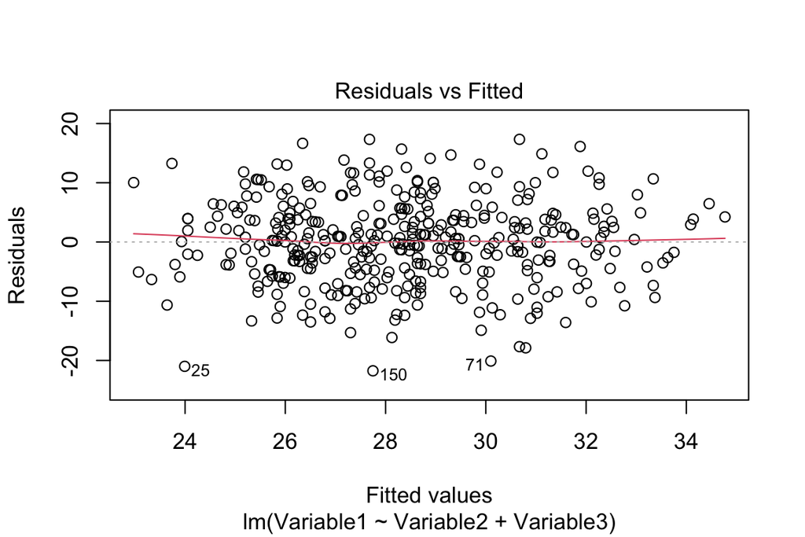

```r
plot(m1, 1)
```

**Interpreting R Plot**

Assumptions are met when the red line is flat and horizontal (linearity) and the data points are equally and randomly spread (homoscedasticity).

Alternatively you can use the scale-location plot to examine homoscedasticity. It plots the square rooted **standardized** residual vs. predicted values.

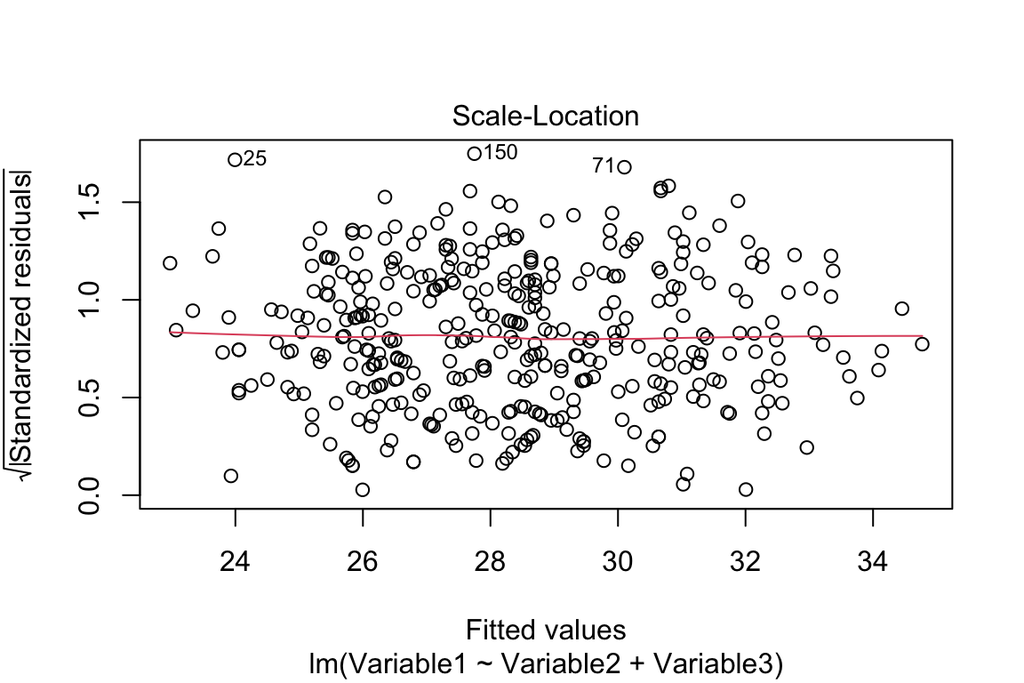

```r
plot(m1, 3)
```

**Interpreting R Plot**

Homoscedasticity Assumption is met when the data points are equally and randomly spread.

## 4.2 Normality of Residuals

Normality of Residuals can be examined by plotting the standardised residuals using a QQ plot.

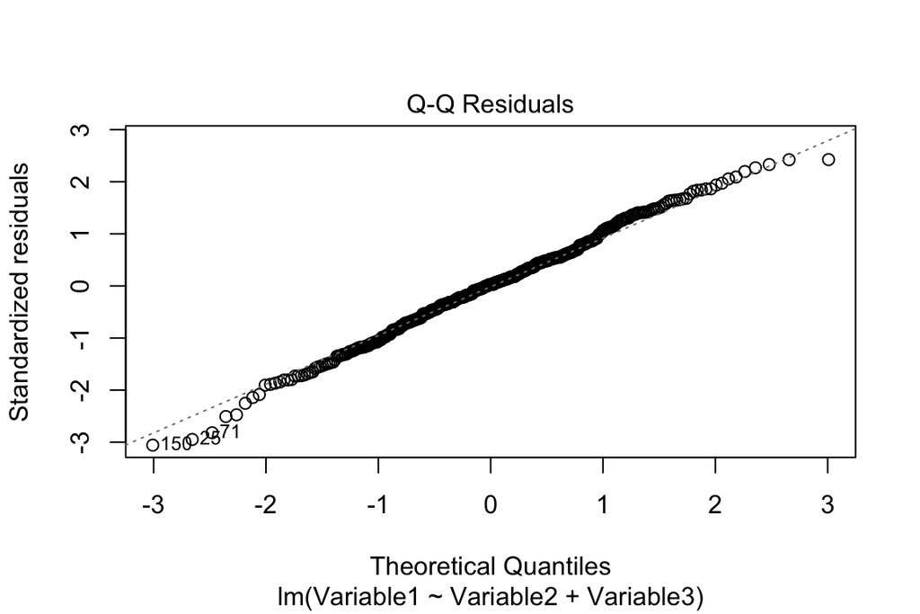

```r
plot(m1, 2)
```

**Interpreting R Plot**

Normality of Residuals Assumption is met when the data points observations fall along the diagonal straight line.

## 4.3 Multicollinearity

Several ways to check for multicollinearity, including:

- Correlation Matrix
- Variance Inflation Factors (VIF)

### 4.3.1 Correlation Matrix

We can use the `cor()` and `corrplot()` functions to create a plot of a correlation matrix.

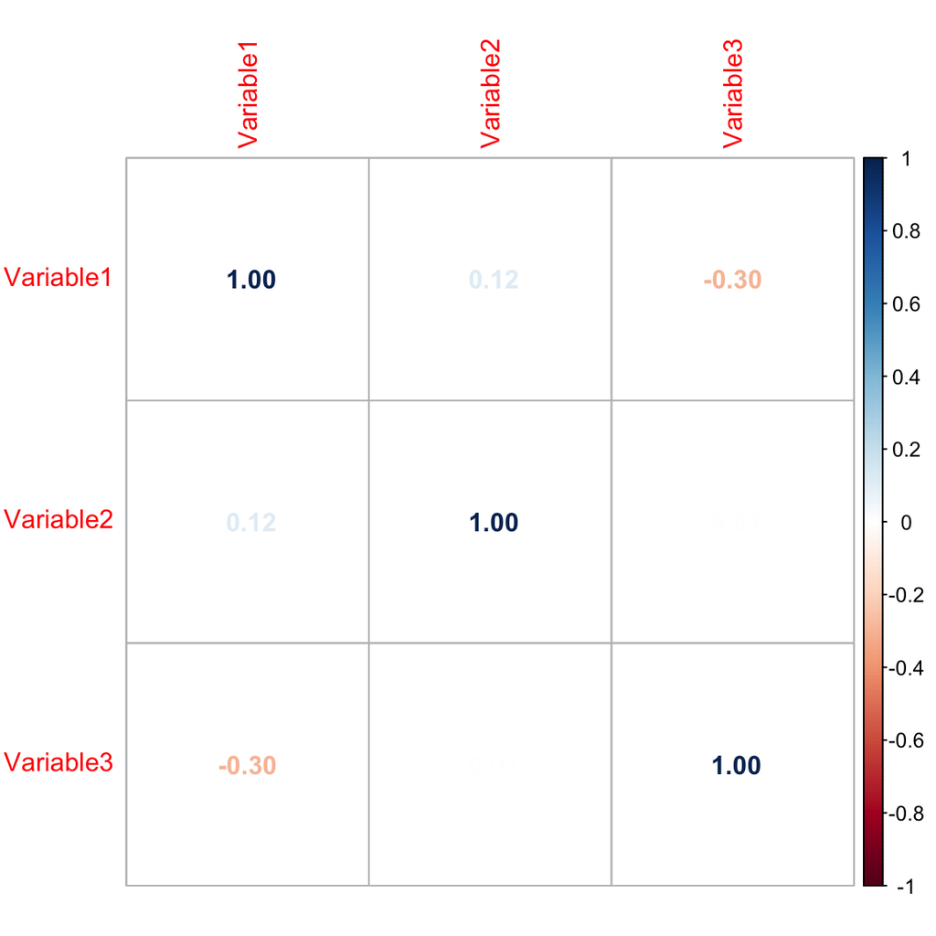

```r
corrplot(cor(d[, .(Variable1, Variable2, Variable3)]), method = "number")
```

**Interpreting R Plot**

Multicollinearity is indicated when the correlation between two (predictor) variables is below -0.9 or above +0.9.

### 4.3.2 Variance Inflation Factors

We can use the `ols_vif_tol()` function from the `olsrr` package to calculate the Tolerance and the Variance Inflation Factor values.

```r
ols_vif_tol(m1)
```

```
##   Variables Tolerance VIF
## 1 Variable2    0.9999   1
## 2 Variable3    0.9999   1
```

**Interpreting R Output**

Multicollinearity may be indicated when VIF > 10.

## 4.4 Bivariate and Multivariate Outliers

We learnt how to inspect univariate outliers during week 5. For multiple regression, we also check for either bivariate or multivariate outliers.

- For bivariate outliers, we can simply use the scatter plot.
- For multivariate outliers, we can use Cook’s distance.

### 4.4.1 Cook’s distance

Chart of Cook’s distance `ols_plot_cooksd_chart()` can be used to detect observations that strongly influence fitted values of the model. A data point having a large Cook’s D indicates that the data point strongly influences the fitted values.

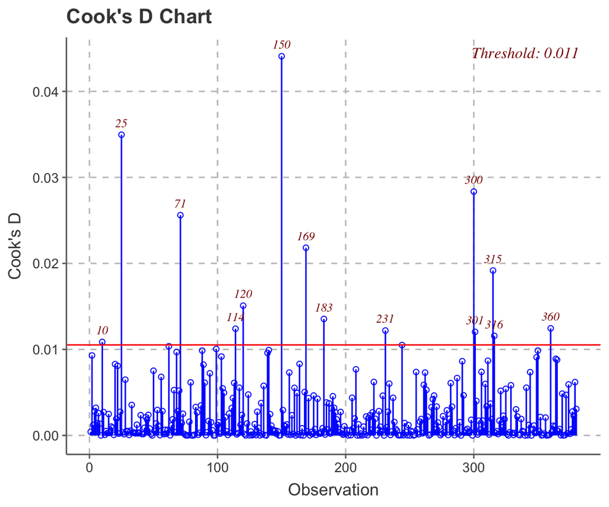

```r
ols_plot_cooksd_chart(m1)
```

If we want a list of participants with outliers, we can use this code `subset(ols_prep_outlier_obs(ols_prep_cdplot_data(model_name)), color == "outlier")`. The `obs` column indicate the IDs of participants with outliers.

```r
subset(ols_prep_outlier_obs(ols_prep_cdplot_data(m1)), color == "outlier")
```

```
##     obs      cd   color fct_color txt
## 10   10 0.01087 outlier   outlier  10
## 25   25 0.03496 outlier   outlier  25
## 71   71 0.02561 outlier   outlier  71
## 114 114 0.01241 outlier   outlier 114
## 120 120 0.01509 outlier   outlier 120
## 150 150 0.04408 outlier   outlier 150
## 169 169 0.02182 outlier   outlier 169
## 183 183 0.01354 outlier   outlier 183
## 231 231 0.01220 outlier   outlier 231
## 300 300 0.02835 outlier   outlier 300
## 301 301 0.01204 outlier   outlier 301
## 315 315 0.01917 outlier   outlier 315
## 316 316 0.01158 outlier   outlier 316
## 360 360 0.01245 outlier   outlier 360
```

As a rule of thumb, Cook’s Distance over $4/n$ (where n is sample size) is considered to be an outlier. We can also obtain this value using this code `ols_prep_cdplot_data(model_name)$ts`.

```r
ols_prep_cdplot_data(m1)$ts
```

```
## [1] 0.01053
```

**Interpreting R Output**

**Tips**

Always check for univariate and either bivarite or multivariate outliers for your multiple regression model.

## 4.5 Assumptions - Putting it all together

We can use the `ols_plot_diagnostics()` function from the `olsrr` package to obtain many relevant plots for checking assumptions. Plots that may be helpful include:

- Residual vs Predicted Values - Linearity and Homoscedasticity
- Normal Q-Q Plot & Residual Histogram - Normality of Residuals
- Cook’s D Chart - Multivariate Outliers

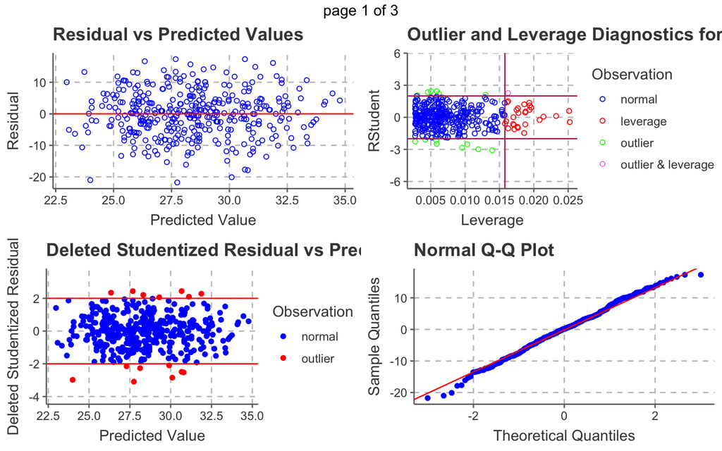

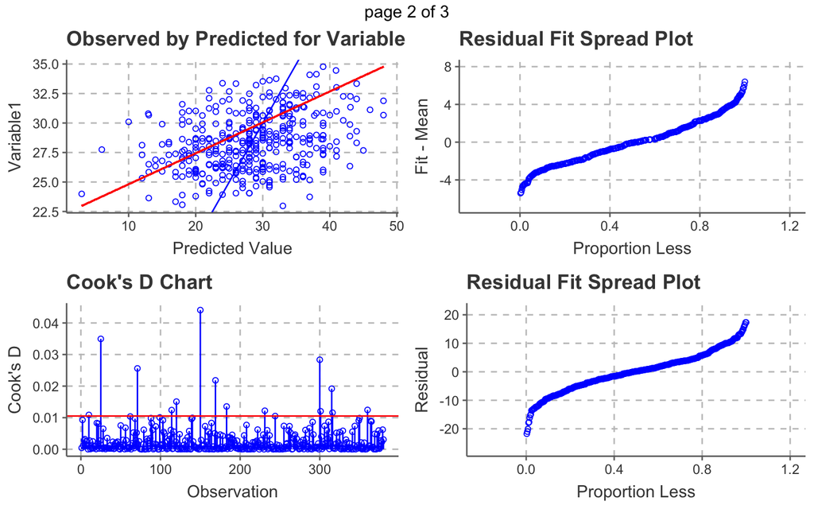

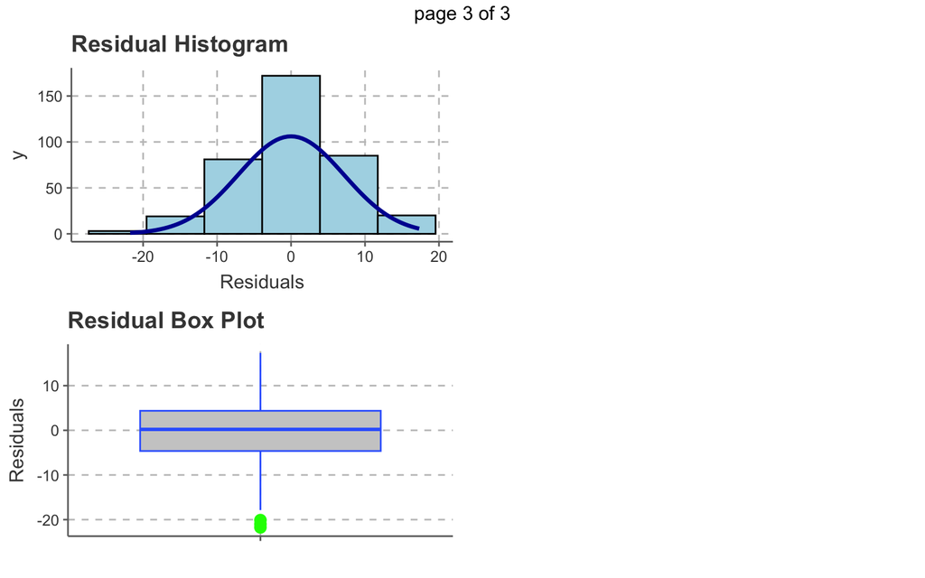

```r
ols_plot_diagnostics(m1)
```

**Tips**

Assumptions checking for Multiple Regression:

- Normality of Outcome Variable
- Normality of Residuals
- Linearity
- Homoscedasticity
- Univariate and Bivariate/Multivariate Outliers

# 5 Multiple Regression with Continuous and Categorical Predictors

## 5.1 Dummy Coding - Categorical/Factor variables

Factor variables in `R` are used to represent categorical data. Factors store data as integer values (i.e., levels) with a corresponding set of character values (i.e., labels) to use when the factor is displayed. While factors look like character vectors, they are actually integers. For example, when we make the sex variable a factor variable, by setting male = 0 and female = 1, sex variable will be displayed as male/female in `R`. However, when it is entered into a regression model, `R` will help us do dummy coding. Dummy coding is helpful as you can examine categorical variable in a regression model. That’s why we usually convert categorical data into factors.

Let’s try this on the `Sex` variable. First, take a look at how it is currently coded using the `table()` function.

```r
class(d$Sex)
```

```
## [1] "integer"
```

```r
table(d$Sex)
```

```
##
##   0   1
##  93 287
```

We create a factor using the `factor()` function.

```r
d[, Sex := factor(
  Sex,
  levels = c(0,1),
  labels = c("Male", "Female"))]
```

See how it is now after being recoded.

```r
class(d$Sex)
```

```
## [1] "factor"
```

```r
table(d$Sex)
```

```
##
##   Male Female
##     93    287
```

In the datset, we can see that the labels, rather than levels, are displayed.

```r
# View(d)
```

**You Try It**

Convert the `BornAUS` variable into a factor. You can keep the name, or give it a new name.

## 5.2 Create Categorical Variables from Continuous Variables

```r
d[, Mark := rep(sample(0:100), length.out = nrow(d))]
```

We can create a new categorical variable called `Grade` that group these people according to their marks using the `cut()` function.

```r
d[, Grade := cut(Mark,
                 breaks = c(-Inf, 49.99, 59.99, 69.99, 79.99, Inf),
                 labels = c("N", "P", "C", "D", "HD"))]
```

```r
table(d$Grade)
```

```
##
##   N   P   C   D  HD
## 187  37  39  37  80
```

## 5.3 Changing the reference level of a factor

Factors in `R` come in two varieties: ordered (e.g., small, medium, large) and unordered (e.g., rose, daisy, lavender). For dummy variables, it is often helpful to set a reference level or “baseline” value. For example, consider our categorical predictor variable “Sex” with levels “Male” and “Female”. If “Male” is our reference, the model output for regression will give us a coefficient for “Female”, which can be interpreted as the difference in the outcome between Female and Male.

When there are more than two levels, this reference level becomes more useful for interpretation. For example, we may have a specific group that we want to compare against the other groups. Let’s take a look at the Alcohol Risk Category variable in the PSY3062 dataset.

```r
class(d$AUDITCat)
```

```
## [1] "character"
```

Since it is “character” variable, not a integer variable as “Sex”, we can’t assign levels/labels to it. We will go head to convert it to a factor.

```r
d$AUDITCat <- as.factor(d$AUDITCat)
str(d$AUDITCat)
```

```
##  Factor w/ 3 levels "Abstainer","At Risk",..: 3 3 3 3 3 3 2 1 3 3 ...
```

This works fine, but what if we want to compare all groups with the “At risk” group?

```r
d[, AUDITCat := relevel(AUDITCat, ref = "At Risk")]
str(d$AUDITCat)
```

```
##  Factor w/ 3 levels "At Risk","Abstainer",..: 3 3 3 3 3 3 1 2 3 3 ...
```

## 5.4 Model

```r
m2 <- lm(Variable1 ~ Variable2 + AUDITCat, data = d)
summary(m2)
```

```
##
## Call:
## lm(formula = Variable1 ~ Variable2 + AUDITCat, data = d)
##
## Residuals:
##     Min      1Q  Median      3Q     Max
## -23.923  -4.905   0.033   5.050  19.806
##
## Coefficients:
##                   Estimate Std. Error t value Pr(>|t|)
## (Intercept)         21.767      3.478    6.26  1.1e-09 ***
## Variable2            0.409      0.176    2.32    0.021 *
## AUDITCatAbstainer   -0.114      1.377   -0.08    0.934
## AUDITCatModerate    -1.386      1.241   -1.12    0.265
## ---
## Signif. codes:  0 '***' 0.001 '**' 0.01 '*' 0.05 '.' 0.1 ' ' 1
##
## Residual standard error: 7.49 on 376 degrees of freedom
## Multiple R-squared:  0.0207, Adjusted R-squared:  0.0129
## F-statistic: 2.65 on 3 and 376 DF,  p-value: 0.0488
```

In the above output,

You can see that there is no row showing result for the At Risk group. This is because in the model, each dummy variable (Abstainer and Moderate, respectively) is compared with the reference group (At Risk). The coefficients tell us the difference in the outcome (Variable1) between the each group (dummy = 1) and the reference group (dummy = 0). These results are not significant, but if they are, we can write them up as below.

**Sample Write-up for Dummy variables**

A multiple regression model was used to examine whether Variable2 and Alcohol Risk predict Variable1. The results showed that, Abstainer had -0.11 lower Variable1 than the At Risk group [95% CI -2.82, 2.59], p = .934. The Moderate group also had lower Variable1 than the At Risk group (b = -1.39 [95% CI -3.83, 1.05], p = .265).

*Notes. Results are not significant, this write-up is only for teaching purposes.*